# fifa_dataset

## Fifa_Project using matplotlib, seaborn

```python
import matplotlib.pyplot as plt # For creating plots and visualizations
import pandas as pd  # For data manipulation and analysis
import seaborn as sns          # For advanced visualizations and statistical plots
```

Exploratory Data Analysis(EDA)

```python
df=pd.read_csv('C://Users//EliteBook//Desktop//ds//fifa_project.csv',encoding='unicode_escape')
```

```python
df.head()
```

|  | Unnamed: 0 | ID | Name | Age | Photo | Nationality | Flag | Overall | Potential | Club | ... | Composure | Marking | StandingTackle | SlidingTackle | GKDiving | GKHandling | GKKicking | GKPositioning | GKReflexes | Release Clause |
| --- | --- | --- | --- | --- | --- | --- | --- | --- | --- | --- | --- | --- | --- | --- | --- | --- | --- | --- | --- | --- | --- |
| 0 | 0 | 158023 | L. Messi | 31 | https://cdn.sofifa.org/players/4/19/158023.png | Argentina | https://cdn.sofifa.org/flags/52.png | 94 | 94 | FC Barcelona | ... | 96.0 | 33.0 | 28.0 | 26.0 | 6.0 | 11.0 | 15.0 | 14.0 | 8.0 | 226.5M |
| 1 | 1 | 20801 | Cristiano Ronaldo | 33 | https://cdn.sofifa.org/players/4/19/20801.png | Portugal | https://cdn.sofifa.org/flags/38.png | 94 | 94 | Juventus | ... | 95.0 | 28.0 | 31.0 | 23.0 | 7.0 | 11.0 | 15.0 | 14.0 | 11.0 | 127.1M |
| 2 | 2 | 190871 | Neymar Jr | 26 | https://cdn.sofifa.org/players/4/19/190871.png | Brazil | https://cdn.sofifa.org/flags/54.png | 92 | 93 | Paris Saint-Germain | ... | 94.0 | 27.0 | 24.0 | 33.0 | 9.0 | 9.0 | 15.0 | 15.0 | 11.0 | 228.1M |
| 3 | 3 | 193080 | De Gea | 27 | https://cdn.sofifa.org/players/4/19/193080.png | Spain | https://cdn.sofifa.org/flags/45.png | 91 | 93 | Manchester United | ... | 68.0 | 15.0 | 21.0 | 13.0 | 90.0 | 85.0 | 87.0 | 88.0 | 94.0 | 138.6M |
| 4 | 4 | 192985 | K. De Bruyne | 27 | https://cdn.sofifa.org/players/4/19/192985.png | Belgium | https://cdn.sofifa.org/flags/7.png | 91 | 92 | Manchester City | ... | 88.0 | 68.0 | 58.0 | 51.0 | 15.0 | 13.0 | 5.0 | 10.0 | 13.0 | 196.4M |

5 rows × 89 columns

# 1. Which country has the most number of players

```python
country_with_most_players = df['Nationality'].value_counts().idxmax()
print(f"The country with the most number of players is: {country_with_most_players}")
```

```
The country with the most number of players is: England
```

# 2. Plot a bar chart of 5 top countries with the most number of players

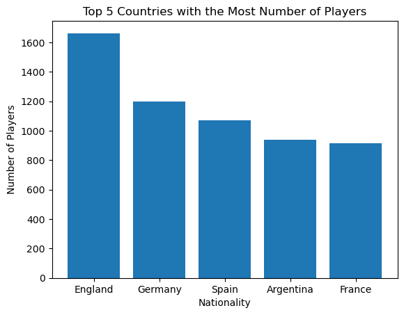

```python
top_countries = df['Nationality'].value_counts().nlargest(5)
plt.bar(top_countries.index, top_countries.values)
plt.xlabel('Nationality')
plt.ylabel('Number of Players')
plt.title('Top 5 Countries with the Most Number of Players')
plt.show()
```

Bar chart showing the 5 countries with the highest number of players. England is the 1st position

Column Names

```python
df.columns
```

```
Index(['Unnamed: 0', 'ID', 'Name', 'Age', 'Photo', 'Nationality', 'Flag',
       'Overall', 'Potential', 'Club', 'Club Logo', 'Value', 'Wage', 'Special',
       'Preferred Foot', 'International Reputation', 'Weak Foot',
       'Skill Moves', 'Work Rate', 'Body Type', 'Real Face', 'Position',
       'Jersey Number', 'Joined', 'Loaned From', 'Contract Valid Until',
       'Height', 'Weight', 'LS', 'ST', 'RS', 'LW', 'LF', 'CF', 'RF', 'RW',
       'LAM', 'CAM', 'RAM', 'LM', 'LCM', 'CM', 'RCM', 'RM', 'LWB', 'LDM',
       'CDM', 'RDM', 'RWB', 'LB', 'LCB', 'CB', 'RCB', 'RB', 'Crossing',
       'Finishing', 'HeadingAccuracy', 'ShortPassing', 'Volleys', 'Dribbling',
       'Curve', 'FKAccuracy', 'LongPassing', 'BallControl', 'Acceleration',
       'SprintSpeed', 'Agility', 'Reactions', 'Balance', 'ShotPower',
       'Jumping', 'Stamina', 'Strength', 'LongShots', 'Aggression',
       'Interceptions', 'Positioning', 'Vision', 'Penalties', 'Composure',
       'Marking', 'StandingTackle', 'SlidingTackle', 'GKDiving', 'GKHandling',
       'GKKicking', 'GKPositioning', 'GKReflexes', 'Release Clause'],
      dtype='object')
```

# 3. Display the player with the highest salary

```python
#Converte
df_sorted = df.sort_values(by='Wage', ascending=False)


highest_salary_player = df_sorted.iloc[0]['Name']
print("Player with the highest salary:", highest_salary_player)
```

```
Player with the highest salary: L. Messi
```

The player with the highest salary is "L. Messi" with a salary of "€565K".

# 4. Plot a histogram to get the salary range of the players

[figure not shown]

```python
plt.hist(df['Wage'], bins=20)
plt.xlabel('Salary')
plt.ylabel('Number of Players')
plt.title('Salary Range of FIFA Players')
plt.show()
```

Histogram depicting the distribution of player salaries.

# 5.Who is the tallest player in the fifa players?

```python
#creating a smaller data for easy calculation
df_ht = pd.read_csv('C://Users//EliteBook//Desktop//ds//fifa_project.csv',encoding='unicode_escape', usecols = ['Name','Height'])

#converting type of height to float for comparison
df_ht['Height'] = df_ht['Height'].replace({"'": "."}, regex=True).astype(float)

# sorting based on height
print("The tallest player with height in feet:")
df_ht.sort_values(by=['Height'], ascending = False).iloc[0]
```

```
The tallest player with height in feet:
```

```
Name      T. Holý
Height        6.9
Name: 11614, dtype: object
```

The tallest player in the FIFA dataset is "T.Holy" with a height of 6.9 feet.

# 6. Which club has the most number of players?

```python
club_with_most_players = df['Club'].value_counts().idxmax()
print(f"The club with the most number of players is: {club_with_most_players}")
```

```
The club with the most number of players is: FC Barcelona
```

The club with the most players in the dataset is FC Barcelona.

# 7. Which foot is most preferred by the players? Draw a bar chart for preferred foot

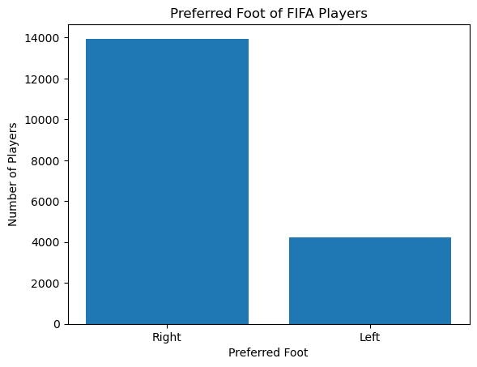

```python
preferred_foot_count = df['Preferred Foot'].value_counts()
plt.bar(preferred_foot_count.index, preferred_foot_count.values)
plt.xlabel('Preferred Foot')
plt.ylabel('Number of Players')
plt.title('Preferred Foot of FIFA Players')
plt.show()
```

Bar chart displaying the preferred foot right of players

# Conclusion:

The exploratory data analysis of the FIFA Players Dataset provided valuable insights into the demographics, salaries, physical attributes, and club affiliations of football players. It revealed the top countries with the highest number of players, the highest-paid player, the distribution of player salaries, the tallest player, the club with the most players, and the preferred foot among players.